# RepasoParaParcial_y_PartePractica_al_final

## ANOTACION:

#### 1. Las celdas con Recomendacion, son indicaciones que pongo para que tengan en cuenta para el parcial

#### 2. Las celdas con Repaso son puntos que deberian repasar

#### 3. Las celdas con Ojo son puntos con los que deben tener mucho cuidado

#### 4. POR FAVOR LEAN LOS COMENTARIOS DE LAS CELDAS

**Recomendacion** : Como deberian resolver el parcial y dividir su tiempo el tiempo en el parcial

1. Leer todo el parcial y estimar cuanto se deberian demorar en cada punto
2. Hacer exploracion rapida
3. Mirar que variables estan mas completas y limpiarlas si son necesarias
4. Organizar cada pregunta y irla respondiendo ayudada de celdas de codigo. Esto es importante para que al profesor le sea facil entender lo que se hizo
5. Impartir mas tiempo a las preguntas con mayor porcentaje del parcial

```python
# Importando modulos
import os, sys
import numpy as np
import pandas as pd
import pandas_profiling
```

```python
# module to do statistics
import scipy.stats  as stats

# importing modules for contingency
from scipy.stats import chi2
from scipy.stats import chi2_contingency
```

```python
# Modulos de graficos
import matplotlib
matplotlib.style.use('ggplot')
from matplotlib import pyplot as plt
%matplotlib inline
import seaborn as sns
import bokeh
```

```python
# Funciones adicionales
# funcion de otra persona http://stackoverflow.com/questions/26266362/how-to-count-the-nan-values-in-the-column-in-panda-data-frame"
def missing_values_table(df):
        mis_val = df.isnull().sum()
        mis_val_percent = 100 * df.isnull().sum()/len(df)
        mis_val_table = pd.concat([mis_val, mis_val_percent], axis=1)
        mis_val_table_ren_columns = mis_val_table.rename(
        columns = {0 : 'Missing Values', 1 : '% of Total Values'})
        return mis_val_table_ren_columns
```

**Recomendacion** : Hagan una jupyter notebook con sus funciones o celdas de sus propios notebooks que entiendan para hacer las cosas mas rapido y solo tener que copiar y pegar

**Recomendacion** : Para este parcial es importante el manejo del tiempo para que puedan resolver todas las preguntas

## Parte 1. Importando BD y haciendo exploracion rapida

```python
# Obteniendo datos
pathPrin= '/Users/CamilaMV/Desktop/CDAplicada/Principal.xlsx'
# importar datos y creando dataframe
dfPrin = pd.read_excel(pathPrin)
```

```python
# Revision rapida de las variables
dfPrin.head()
```

|  | Ciudad | Cliente | Localidad_Zona | Sexo | Edad | Rango_Edad | Hijos | Categoria_Cliente | Activo | Paquete | Precio_Semanal_Paquete | Cantidad_Horas_Demandadas | Costo | MedioPago | Puntos_Conexion_Cliente | PQR_Id | PQR_Filtro | Campaña |
| --- | --- | --- | --- | --- | --- | --- | --- | --- | --- | --- | --- | --- | --- | --- | --- | --- | --- | --- |
| 0 | Bogota | C_5871 | Engativa | Hombre | 59.0 | a_Mayor_50 | 3.0 | Fiel | 1 | Basic | 6900 | 5.2 | 3000.4 | Presencial | 2 | NaN | No | NO_Impacto |
| 1 | Bogota 011 | C_8093 | Engativa | Hombre | 52.0 | a_Mayor_50 | 2.0 | Nuevo | 1 | Basic | 6900 | 3.7 | 2501.1 | Presencial | 1 | NaN | No | NO_Impacto |
| 2 | Bogota | C_8387 | Teusaquillo | Hombre | 75.0 | a_Mayor_50 | 4.0 | Fiel | 1 | Basic | 6900 | 14.3 | 4000.9 | NaN | 4 | NaN | No | NO_Impacto |
| 3 | Bogota | C_9658 | Engativa | Hombre | 52.0 | a_Mayor_50 | 1.0 | Fiel | 1 | Basic | 6900 | 2.9 | 3500.3 | Presencial | 3 | NaN | No | NO_Impacto |
| 4 | Bogota | C_9721 | Teusaquillo | Hombre | 62.0 | a_Mayor_50 | 4.0 | Fiel | 1 | Basic | 6900 | 10.1 | 3002.7 | Electronico | 2 | NaN | No | NO_Impacto |

```python
# Revision del tamano de la base de datos
dfPrin.shape
```

```
(2690, 18)
```

**Ojo** : Deteccion de tipos de variable como los importa python, pero este no es necesariamente el perfilamiento de las varaibles

```python
dfPrin.dtypes
```

```
Ciudad                        object
Cliente                       object
Localidad_Zona                object
Sexo                          object
Edad                         float64
Rango_Edad                    object
Hijos                        float64
Categoria_Cliente             object
Activo                         int64
Paquete                       object
Precio_Semanal_Paquete         int64
Cantidad_Horas_Demandadas    float64
Costo                        float64
MedioPago                     object
Puntos_Conexion_Cliente        int64
PQR_Id                        object
PQR_Filtro                    object
Campaña                       object
dtype: object
```

**Recomendacion** : Usen pandas profiling para hacer un analisis de la calidad de la BD rapido

Overview

Dataset info

| Number of variables | 18 |
| --- | --- |
| Number of observations | 2690 |
| Total Missing (%) | 11.0% |
| Total size in memory | 378.4 KiB |
| Average record size in memory | 144.0 B |

Variables types

| Numeric | 6 |
| --- | --- |
| Categorical | 10 |
| Date | 0 |
| Text (Unique) | 1 |
| Rejected | 1 |

Warnings

- `Activo` has constant value 1 Rejected

- `Campaña` has 750 / 27.9% missing values Missing

- `Cantidad_Horas_Demandadas` has 35 / 1.3% zeros

- `Edad` has 750 / 27.9% missing values Missing

- `Hijos` has 750 / 27.9% missing values Missing

- `Hijos` has 757 / 28.1% zeros

- `PQR_Id` has 1563 / 58.1% missing values Missing

- `PQR_Id` has a high cardinality: 321 distinct values Warning

- `Rango_Edad` has 750 / 27.9% missing values Missing

- `Sexo` has 750 / 27.9% missing values Missing

Variables

`Activo`  
Constant

*This variable is constant and should be ignored for analysis*

| Constant value | 1 |
| --- | --- |

Campaña  
Categorical

| Distinct count | 3 |
| --- | --- |
| Unique (%) | 0.2% |
| Missing (%) | 27.9% |
| Missing (n) | 750 |

| NO_Impacto | 1604 |
| --- | --- |
| SI_Impacto | 336 |
| (Missing) | 750 |

Toggle details

| Value | Count | Frequency (%) |  |
| --- | --- | --- | --- |
| NO_Impacto | 1604 | 59.6% |  |
| SI_Impacto | 336 | 12.5% |  |
| (Missing) | 750 | 27.9% |  |

Cantidad_Horas_Demandadas  
Numeric

| Distinct count | 191 |
| --- | --- |
| Unique (%) | 7.1% |
| Missing (%) | 0.0% |
| Missing (n) | 0 |
| Infinite (%) | 0.0% |
| Infinite (n) | 0 |

| Mean | 6.5355 |
| --- | --- |
| Minimum | 0 |
| Maximum | 24 |
| Zeros (%) | 1.3% |

Toggle details

**Statistics**

Quantile statistics

| Minimum | 0 |
| --- | --- |
| 5-th percentile | 1.2 |
| Q1 | 4 |
| Median | 6 |
| Q3 | 8 |
| 95-th percentile | 14.455 |
| Maximum | 24 |
| Range | 24 |
| Interquartile range | 4 |

Descriptive statistics

| Standard deviation | 3.8421 |
| --- | --- |
| Coef of variation | 0.58788 |
| Kurtosis | 0.98362 |
| Mean | 6.5355 |
| MAD | 2.9032 |
| Skewness | 1.0171 |
| Sum | 17581 |
| Variance | 14.762 |
| Memory size | 21.1 KiB |

**Histogram**

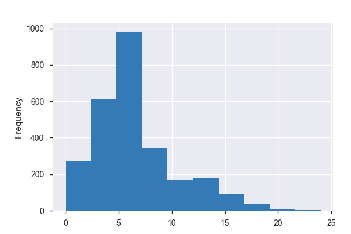

**Common Values**

| Value | Count | Frequency (%) |  |
| --- | --- | --- | --- |
| 6.0 | 257 | 9.6% |  |
| 5.0 | 255 | 9.5% |  |
| 4.0 | 202 | 7.5% |  |
| 7.0 | 72 | 2.7% |  |
| 8.0 | 45 | 1.7% |  |
| 0.0 | 35 | 1.3% |  |
| 1.4 | 34 | 1.3% |  |
| 3.7 | 34 | 1.3% |  |
| 4.8 | 32 | 1.2% |  |
| 2.3 | 30 | 1.1% |  |
| Other values (181) | 1694 | 63.0% |  |

**Extreme Values**

Minimum 5 values

| Value | Count | Frequency (%) |  |
| --- | --- | --- | --- |
| 0.0 | 35 | 1.3% |  |
| 0.1 | 5 | 0.2% |  |
| 0.2 | 2 | 0.1% |  |
| 0.3 | 22 | 0.8% |  |
| 0.4 | 16 | 0.6% |  |

Maximum 5 values

| Value | Count | Frequency (%) |  |
| --- | --- | --- | --- |
| 19.8 | 1 | 0.0% |  |
| 20.1 | 1 | 0.0% |  |
| 21.0 | 2 | 0.1% |  |
| 23.0 | 1 | 0.0% |  |
| 24.0 | 1 | 0.0% |  |

Categoria_Cliente  
Categorical

| Distinct count | 3 |
| --- | --- |
| Unique (%) | 0.1% |
| Missing (%) | 0.0% |
| Missing (n) | 0 |

| Fiel | 1185 |
| --- | --- |
| Nuevo | 754 |
| Flotante | 751 |

Toggle details

| Value | Count | Frequency (%) |  |
| --- | --- | --- | --- |
| Fiel | 1185 | 44.1% |  |
| Nuevo | 754 | 28.0% |  |
| Flotante | 751 | 27.9% |  |

Ciudad  
Categorical

| Distinct count | 4 |
| --- | --- |
| Unique (%) | 0.1% |
| Missing (%) | 0.0% |
| Missing (n) | 0 |

| Bogota | 1679 |
| --- | --- |
| Medellin | 1003 |
| Medellin 05001 | 7 |

Toggle details

| Value | Count | Frequency (%) |  |
| --- | --- | --- | --- |
| Bogota | 1679 | 62.4% |  |
| Medellin | 1003 | 37.3% |  |
| Medellin 05001 | 7 | 0.3% |  |
| Bogota 011 | 1 | 0.0% |  |

Cliente  
Categorical, Unique

| First 3 values |
| --- |
| C_EWX383 |
| C_EWX86 |
| C_1142094 |

| Last 3 values |
| --- |
| C_315870 |
| C_384954 |
| C_1515470 |

Toggle details

First 10 values

| Value | Count | Frequency (%) |  |
| --- | --- | --- | --- |
| C_1000548 | 1 | 0.0% |  |
| C_100096 | 1 | 0.0% |  |
| C_1001068 | 1 | 0.0% |  |
| C_1001672 | 1 | 0.0% |  |
| C_1002827 | 1 | 0.0% |  |

Last 10 values

| Value | Count | Frequency (%) |  |
| --- | --- | --- | --- |
| C_MXE95 | 1 | 0.0% |  |
| C_MXE96 | 1 | 0.0% |  |
| C_MXE97 | 1 | 0.0% |  |
| C_MXE98 | 1 | 0.0% |  |
| C_MXE99 | 1 | 0.0% |  |

Costo  
Numeric

| Distinct count | 1496 |
| --- | --- |
| Unique (%) | 55.6% |
| Missing (%) | 0.0% |
| Missing (n) | 0 |
| Infinite (%) | 0.0% |
| Infinite (n) | 0 |

| Mean | 5588.4 |
| --- | --- |
| Minimum | 2009.9 |
| Maximum | 13790 |
| Zeros (%) | 0.0% |

Toggle details

**Statistics**

Quantile statistics

| Minimum | 2009.9 |
| --- | --- |
| 5-th percentile | 2134.8 |
| Q1 | 2554.4 |
| Median | 6780 |
| Q3 | 7825.5 |
| 95-th percentile | 8544 |
| Maximum | 13790 |
| Range | 11780 |
| Interquartile range | 5271.1 |

Descriptive statistics

| Standard deviation | 2495.2 |
| --- | --- |
| Coef of variation | 0.4465 |
| Kurtosis | -1.5379 |
| Mean | 5588.4 |
| MAD | 2334.3 |
| Skewness | -0.25213 |
| Sum | 15033000 |
| Variance | 6226200 |
| Memory size | 21.1 KiB |

**Histogram**

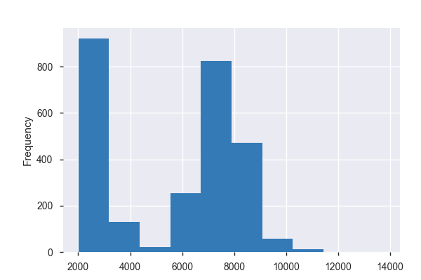

**Common Values**

| Value | Count | Frequency (%) |  |
| --- | --- | --- | --- |
| 7970.0 | 104 | 3.9% |  |
| 7925.0 | 104 | 3.9% |  |
| 7880.0 | 100 | 3.7% |  |
| 3000.1 | 44 | 1.6% |  |
| 2500.1 | 39 | 1.4% |  |
| 3000.2 | 38 | 1.4% |  |
| 2500.2 | 36 | 1.3% |  |
| 3000.0 | 32 | 1.2% |  |
| 2500.0 | 29 | 1.1% |  |
| 7020.0 | 28 | 1.0% |  |
| Other values (1486) | 2136 | 79.4% |  |

**Extreme Values**

Minimum 5 values

| Value | Count | Frequency (%) |  |
| --- | --- | --- | --- |
| 2009.9 | 1 | 0.0% |  |
| 2017.5 | 1 | 0.0% |  |
| 2019.9 | 1 | 0.0% |  |
| 2020.5 | 1 | 0.0% |  |
| 2020.8 | 1 | 0.0% |  |

Maximum 5 values

| Value | Count | Frequency (%) |  |
| --- | --- | --- | --- |
| 10850.0 | 1 | 0.0% |  |
| 10866.1 | 1 | 0.0% |  |
| 11000.0 | 1 | 0.0% |  |
| 11040.0 | 1 | 0.0% |  |
| 13790.0 | 1 | 0.0% |  |

Edad  
Numeric

| Distinct count | 46 |
| --- | --- |
| Unique (%) | 2.4% |
| Missing (%) | 27.9% |
| Missing (n) | 750 |
| Infinite (%) | 0.0% |
| Infinite (n) | 0 |

| Mean | 44.398 |
| --- | --- |
| Minimum | 20 |
| Maximum | 220 |
| Zeros (%) | 0.0% |

Toggle details

**Statistics**

Quantile statistics

| Minimum | 20 |
| --- | --- |
| 5-th percentile | 24 |
| Q1 | 29 |
| Median | 39 |
| Q3 | 55 |
| 95-th percentile | 75 |
| Maximum | 220 |
| Range | 200 |
| Interquartile range | 26 |

Descriptive statistics

| Standard deviation | 17.794 |
| --- | --- |
| Coef of variation | 0.40078 |
| Kurtosis | 17.003 |
| Mean | 44.398 |
| MAD | 14.078 |
| Skewness | 2.226 |
| Sum | 86132 |
| Variance | 316.62 |
| Memory size | 21.1 KiB |

**Histogram**

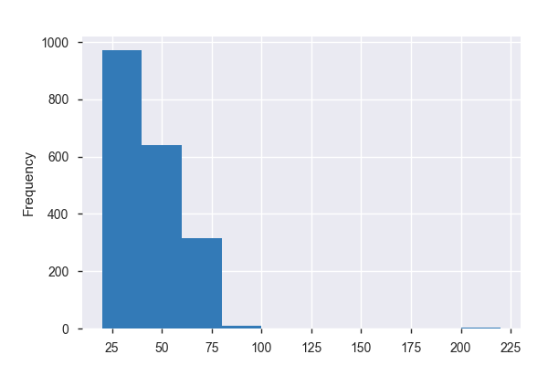

**Common Values**

| Value | Count | Frequency (%) |  |
| --- | --- | --- | --- |
| 28.0 | 122 | 4.5% |  |
| 35.0 | 119 | 4.4% |  |
| 51.0 | 104 | 3.9% |  |
| 25.0 | 101 | 3.8% |  |
| 38.0 | 98 | 3.6% |  |
| 26.0 | 96 | 3.6% |  |
| 52.0 | 91 | 3.4% |  |
| 31.0 | 74 | 2.8% |  |
| 78.0 | 65 | 2.4% |  |
| 39.0 | 61 | 2.3% |  |
| Other values (35) | 1009 | 37.5% |  |
| (Missing) | 750 | 27.9% |  |

**Extreme Values**

Minimum 5 values

| Value | Count | Frequency (%) |  |
| --- | --- | --- | --- |
| 20.0 | 1 | 0.0% |  |
| 22.0 | 38 | 1.4% |  |
| 23.0 | 20 | 0.7% |  |
| 24.0 | 42 | 1.6% |  |
| 25.0 | 101 | 3.8% |  |

Maximum 5 values

| Value | Count | Frequency (%) |  |
| --- | --- | --- | --- |
| 75.0 | 23 | 0.9% |  |
| 78.0 | 65 | 2.4% |  |
| 80.0 | 11 | 0.4% |  |
| 210.0 | 1 | 0.0% |  |
| 220.0 | 3 | 0.1% |  |

Hijos  
Numeric

| Distinct count | 13 |
| --- | --- |
| Unique (%) | 0.7% |
| Missing (%) | 27.9% |
| Missing (n) | 750 |
| Infinite (%) | 0.0% |
| Infinite (n) | 0 |

| Mean | 1.3829 |
| --- | --- |
| Minimum | 0 |
| Maximum | 10 |
| Zeros (%) | 28.1% |

Toggle details

**Statistics**

Quantile statistics

| Minimum | 0 |
| --- | --- |
| 5-th percentile | 0 |
| Q1 | 0 |
| Median | 1 |
| Q3 | 2 |
| 95-th percentile | 4 |
| Maximum | 10 |
| Range | 10 |
| Interquartile range | 2 |

Descriptive statistics

| Standard deviation | 1.3915 |
| --- | --- |
| Coef of variation | 1.0062 |
| Kurtosis | 0.8202 |
| Mean | 1.3829 |
| MAD | 1.2028 |
| Skewness | 0.80005 |
| Sum | 2682.9 |
| Variance | 1.9362 |
| Memory size | 21.1 KiB |

**Histogram**

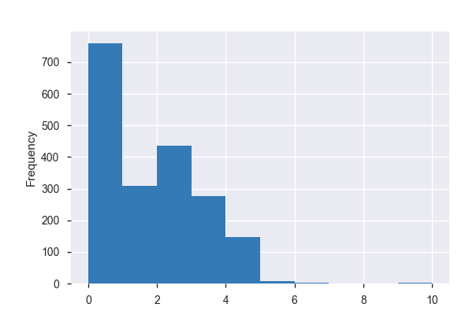

**Common Values**

| Value | Count | Frequency (%) |  |
| --- | --- | --- | --- |
| 0.0 | 757 | 28.1% |  |
| 2.0 | 436 | 16.2% |  |
| 1.0 | 308 | 11.4% |  |
| 3.0 | 276 | 10.3% |  |
| 4.0 | 148 | 5.5% |  |
| 5.0 | 7 | 0.3% |  |
| 6.0 | 2 | 0.1% |  |
| 10.0 | 2 | 0.1% |  |
| 0.1 | 1 | 0.0% |  |
| 0.8 | 1 | 0.0% |  |
| Other values (2) | 2 | 0.1% |  |
| (Missing) | 750 | 27.9% |  |

**Extreme Values**

Minimum 5 values

| Value | Count | Frequency (%) |  |
| --- | --- | --- | --- |
| 0.0 | 757 | 28.1% |  |
| 0.1 | 1 | 0.0% |  |
| 0.8 | 1 | 0.0% |  |
| 1.0 | 308 | 11.4% |  |
| 2.0 | 436 | 16.2% |  |

Maximum 5 values

| Value | Count | Frequency (%) |  |
| --- | --- | --- | --- |
| 5.0 | 7 | 0.3% |  |
| 6.0 | 2 | 0.1% |  |
| 7.0 | 1 | 0.0% |  |
| 8.0 | 1 | 0.0% |  |
| 10.0 | 2 | 0.1% |  |

Localidad_Zona  
Categorical

| Distinct count | 11 |
| --- | --- |
| Unique (%) | 0.4% |
| Missing (%) | 0.7% |
| Missing (n) | 19 |

| Engativa | 659 |
| --- | --- |
| Teusaquillo | 605 |
| Suba | 431 |
| Other values (7) | 976 |

Toggle details

| Value | Count | Frequency (%) |  |
| --- | --- | --- | --- |
| Engativa | 659 | 24.5% |  |
| Teusaquillo | 605 | 22.5% |  |
| Suba | 431 | 16.0% |  |
| Barrios Unidos | 254 | 9.4% |  |
| Noroccidental | 150 | 5.6% |  |
| Nororiental | 149 | 5.5% |  |
| Centro Oriental | 143 | 5.3% |  |
| Suroccidental | 140 | 5.2% |  |
| Centro Occidental | 72 | 2.7% |  |
| Suroriental | 68 | 2.5% |  |
| (Missing) | 19 | 0.7% |  |

MedioPago  
Categorical

| Distinct count | 3 |
| --- | --- |
| Unique (%) | 0.1% |
| Missing (%) | 0.1% |
| Missing (n) | 3 |

| Electronico | 1396 |
| --- | --- |
| Presencial | 1291 |
| (Missing) | 3 |

Toggle details

| Value | Count | Frequency (%) |  |
| --- | --- | --- | --- |
| Electronico | 1396 | 51.9% |  |
| Presencial | 1291 | 48.0% |  |
| (Missing) | 3 | 0.1% |  |

PQR_Filtro  
Categorical

| Distinct count | 2 |
| --- | --- |
| Unique (%) | 0.1% |
| Missing (%) | 0.0% |
| Missing (n) | 0 |

| No | 1563 |
| --- | --- |
| Si | 1127 |

Toggle details

| Value | Count | Frequency (%) |  |
| --- | --- | --- | --- |
| No | 1563 | 58.1% |  |
| Si | 1127 | 41.9% |  |

PQR_Id  
Categorical

| Distinct count | 321 |
| --- | --- |
| Unique (%) | 28.5% |
| Missing (%) | 58.1% |
| Missing (n) | 1563 |

| A0A28865923 | 340 |
| --- | --- |
| PRQA255 | 13 |
| PRQA230 | 13 |
| Other values (317) | 761 |
| (Missing) | 1563 |

Toggle details

| Value | Count | Frequency (%) |  |
| --- | --- | --- | --- |
| A0A28865923 | 340 | 12.6% |  |
| PRQA255 | 13 | 0.5% |  |
| PRQA230 | 13 | 0.5% |  |
| PRQA236 | 11 | 0.4% |  |
| A30220A8 | 11 | 0.4% |  |
| A30220A7 | 11 | 0.4% |  |
| A3022023 | 11 | 0.4% |  |
| A30220A5 | 10 | 0.4% |  |
| PRQA233 | 10 | 0.4% |  |
| A302202A | 10 | 0.4% |  |
| Other values (310) | 687 | 25.5% |  |
| (Missing) | 1563 | 58.1% |  |

Paquete  
Categorical

| Distinct count | 3 |
| --- | --- |
| Unique (%) | 0.1% |
| Missing (%) | 0.0% |
| Missing (n) | 0 |

| Premium | 1360 |
| --- | --- |
| Basic | 814 |
| Modular | 516 |

Toggle details

| Value | Count | Frequency (%) |  |
| --- | --- | --- | --- |
| Premium | 1360 | 50.6% |  |
| Basic | 814 | 30.3% |  |
| Modular | 516 | 19.2% |  |

Precio_Semanal_Paquete  
Numeric

| Distinct count | 445 |
| --- | --- |
| Unique (%) | 16.5% |
| Missing (%) | 0.0% |
| Missing (n) | 0 |
| Infinite (%) | 0.0% |
| Infinite (n) | 0 |

| Mean | 12747 |
| --- | --- |
| Minimum | 2412 |
| Maximum | 36780 |
| Zeros (%) | 0.0% |

Toggle details

**Statistics**

Quantile statistics

| Minimum | 2412 |
| --- | --- |
| 5-th percentile | 3184.4 |
| Q1 | 6900 |
| Median | 12500 |
| Q3 | 17200 |
| 95-th percentile | 27000 |
| Maximum | 36780 |
| Range | 34368 |
| Interquartile range | 10300 |

Descriptive statistics

| Standard deviation | 7935 |
| --- | --- |
| Coef of variation | 0.62248 |
| Kurtosis | -0.60271 |
| Mean | 12747 |
| MAD | 6105.7 |
| Skewness | 0.71088 |
| Sum | 34290498 |
| Variance | 62965000 |
| Memory size | 21.1 KiB |

**Histogram**

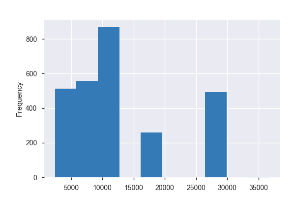

**Common Values**

| Value | Count | Frequency (%) |  |
| --- | --- | --- | --- |
| 12500 | 868 | 32.3% |  |
| 6900 | 556 | 20.7% |  |
| 27000 | 492 | 18.3% |  |
| 17200 | 258 | 9.6% |  |
| 3166 | 3 | 0.1% |  |
| 3443 | 3 | 0.1% |  |
| 3347 | 3 | 0.1% |  |
| 2975 | 3 | 0.1% |  |
| 3034 | 3 | 0.1% |  |
| 3614 | 3 | 0.1% |  |
| Other values (435) | 498 | 18.5% |  |

**Extreme Values**

Minimum 5 values

| Value | Count | Frequency (%) |  |
| --- | --- | --- | --- |
| 2412 | 1 | 0.0% |  |
| 2422 | 1 | 0.0% |  |
| 2501 | 1 | 0.0% |  |
| 2552 | 1 | 0.0% |  |
| 2585 | 1 | 0.0% |  |

Maximum 5 values

| Value | Count | Frequency (%) |  |
| --- | --- | --- | --- |
| 15800 | 1 | 0.0% |  |
| 17200 | 258 | 9.6% |  |
| 27000 | 492 | 18.3% |  |
| 36750 | 1 | 0.0% |  |
| 36780 | 1 | 0.0% |  |

Puntos_Conexion_Cliente  
Numeric

| Distinct count | 24 |
| --- | --- |
| Unique (%) | 0.9% |
| Missing (%) | 0.0% |
| Missing (n) | 0 |
| Infinite (%) | 0.0% |
| Infinite (n) | 0 |

| Mean | 2.7059 |
| --- | --- |
| Minimum | 1 |
| Maximum | 58 |
| Zeros (%) | 0.0% |

Toggle details

**Statistics**

Quantile statistics

| Minimum | 1 |
| --- | --- |
| 5-th percentile | 1 |
| Q1 | 1 |
| Median | 2 |
| Q3 | 3 |
| 95-th percentile | 6 |
| Maximum | 58 |
| Range | 57 |
| Interquartile range | 2 |

Descriptive statistics

| Standard deviation | 2.7881 |
| --- | --- |
| Coef of variation | 1.0303 |
| Kurtosis | 135.83 |
| Mean | 2.7059 |
| MAD | 1.4016 |
| Skewness | 9.1483 |
| Sum | 7279 |
| Variance | 7.7733 |
| Memory size | 21.1 KiB |

**Histogram**

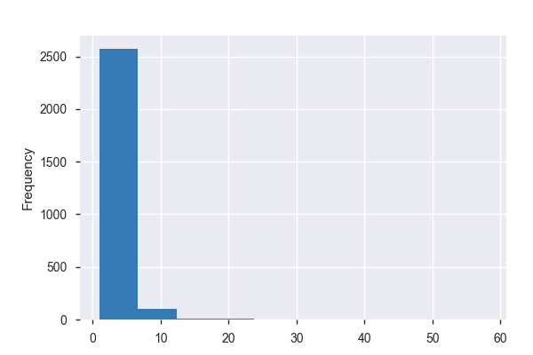

**Common Values**

| Value | Count | Frequency (%) |  |
| --- | --- | --- | --- |
| 1 | 786 | 29.2% |  |
| 2 | 771 | 28.7% |  |
| 3 | 635 | 23.6% |  |
| 4 | 192 | 7.1% |  |
| 5 | 151 | 5.6% |  |
| 8 | 42 | 1.6% |  |
| 7 | 37 | 1.4% |  |
| 6 | 35 | 1.3% |  |
| 9 | 15 | 0.6% |  |
| 12 | 4 | 0.1% |  |
| Other values (14) | 22 | 0.8% |  |

**Extreme Values**

Minimum 5 values

| Value | Count | Frequency (%) |  |
| --- | --- | --- | --- |
| 1 | 786 | 29.2% |  |
| 2 | 771 | 28.7% |  |
| 3 | 635 | 23.6% |  |
| 4 | 192 | 7.1% |  |
| 5 | 151 | 5.6% |  |

Maximum 5 values

| Value | Count | Frequency (%) |  |
| --- | --- | --- | --- |
| 25 | 3 | 0.1% |  |
| 45 | 1 | 0.0% |  |
| 47 | 1 | 0.0% |  |
| 48 | 1 | 0.0% |  |
| 58 | 1 | 0.0% |  |

Rango_Edad  
Categorical

| Distinct count | 4 |
| --- | --- |
| Unique (%) | 0.2% |
| Missing (%) | 27.9% |
| Missing (n) | 750 |

| a_Mayor_50 | 728 |
| --- | --- |
| b_Menor_50_mayor_30 | 689 |
| c_Menor_30 | 523 |
| (Missing) | 750 |

Toggle details

| Value | Count | Frequency (%) |  |
| --- | --- | --- | --- |
| a_Mayor_50 | 728 | 27.1% |  |
| b_Menor_50_mayor_30 | 689 | 25.6% |  |
| c_Menor_30 | 523 | 19.4% |  |
| (Missing) | 750 | 27.9% |  |

Sexo  
Categorical

| Distinct count | 3 |
| --- | --- |
| Unique (%) | 0.2% |
| Missing (%) | 27.9% |
| Missing (n) | 750 |

| Hombre | 1137 |
| --- | --- |
| Mujer | 803 |
| (Missing) | 750 |

Toggle details

| Value | Count | Frequency (%) |  |
| --- | --- | --- | --- |
| Hombre | 1137 | 42.3% |  |
| Mujer | 803 | 29.9% |  |
| (Missing) | 750 | 27.9% |  |

Sample

|  | Ciudad | Cliente | Localidad_Zona | Sexo | Edad | Rango_Edad | Hijos | Categoria_Cliente | Activo | Paquete | Precio_Semanal_Paquete | Cantidad_Horas_Demandadas | Costo | MedioPago | Puntos_Conexion_Cliente | PQR_Id | PQR_Filtro | Campaña |
| --- | --- | --- | --- | --- | --- | --- | --- | --- | --- | --- | --- | --- | --- | --- | --- | --- | --- | --- |
| 0 | Bogota | C_5871 | Engativa | Hombre | 59.0 | a_Mayor_50 | 3.0 | Fiel | 1 | Basic | 6900 | 5.2 | 3000.4 | Presencial | 2 | NaN | No | NO_Impacto |
| 1 | Bogota 011 | C_8093 | Engativa | Hombre | 52.0 | a_Mayor_50 | 2.0 | Nuevo | 1 | Basic | 6900 | 3.7 | 2501.1 | Presencial | 1 | NaN | No | NO_Impacto |
| 2 | Bogota | C_8387 | Teusaquillo | Hombre | 75.0 | a_Mayor_50 | 4.0 | Fiel | 1 | Basic | 6900 | 14.3 | 4000.9 | NaN | 4 | NaN | No | NO_Impacto |
| 3 | Bogota | C_9658 | Engativa | Hombre | 52.0 | a_Mayor_50 | 1.0 | Fiel | 1 | Basic | 6900 | 2.9 | 3500.3 | Presencial | 3 | NaN | No | NO_Impacto |
| 4 | Bogota | C_9721 | Teusaquillo | Hombre | 62.0 | a_Mayor_50 | 4.0 | Fiel | 1 | Basic | 6900 | 10.1 | 3002.7 | Electronico | 2 | NaN | No | NO_Impacto |

```python
# Usando pandas profiling
pandas_profiling.ProfileReport(dfPrin)
```

```python
# Mirando missing values por variable
missing_values_table(dfPrin)
```

|  | Missing Values | % of Total Values |
| --- | --- | --- |
| Ciudad | 0 | 0.000000 |
| Cliente | 0 | 0.000000 |
| Localidad_Zona | 19 | 0.706320 |
| Sexo | 750 | 27.881041 |
| Edad | 750 | 27.881041 |
| Rango_Edad | 750 | 27.881041 |
| Hijos | 750 | 27.881041 |
| Categoria_Cliente | 0 | 0.000000 |
| Activo | 0 | 0.000000 |
| Paquete | 0 | 0.000000 |
| Precio_Semanal_Paquete | 0 | 0.000000 |
| Cantidad_Horas_Demandadas | 0 | 0.000000 |
| Costo | 0 | 0.000000 |
| MedioPago | 3 | 0.111524 |
| Puntos_Conexion_Cliente | 0 | 0.000000 |
| PQR_Id | 1563 | 58.104089 |
| PQR_Filtro | 0 | 0.000000 |
| Campaña | 750 | 27.881041 |

```python
# Luego de mirar los missing values, solo explorar las variables problema en vez de todo
dfPrin.Localidad_Zona.unique()
```

```
array(['Engativa', 'Teusaquillo', 'Suba', 'Barrios Unidos', 'Nororiental',
       'Noroccidental', 'Suroccidental', 'Suroriental',
       'Centro Occidental', 'Centro Oriental', nan], dtype=object)
```

```python
# mirando Sexo
dfPrin.Sexo.unique()
```

```
array(['Hombre', 'Mujer', nan], dtype=object)
```

```python
# mirando Edad
dfPrin.Edad.unique()
```

```
array([  59.,   52.,   75.,   62.,   78.,   54.,   55.,   51.,   69.,
         65.,   42.,   58.,   38.,   39.,   35.,   49.,   34.,   31.,
         37.,   48.,   36.,   25.,   24.,   29.,   26.,   28.,   27.,
         22.,   23.,  220.,   71.,   80.,   74.,   53.,   68.,   56.,
         63.,   57.,   72.,   66.,   46.,   45.,   47.,  210.,   20.,   nan])
```

#### Hay valores de 210 en la edad que se deberia cambiar

```python
# mirando Hijos
dfPrin.Hijos.unique()
```

```
array([  3. ,   2. ,   4. ,   1. ,   0. ,   0.8,   0.1,  10. ,   5. ,
         6. ,   7. ,   8. ,   nan])
```

#### Hay valores de 0.1 hijos

```python
dfPrin.MedioPago.unique()
```

```
array(['Presencial', nan, 'Electronico'], dtype=object)
```

```python
dfPrin.PQR_Id.unique()
```

[output not shown]

[output cut: 19 more lines]

[output not shown]

```python
dfPrin.Campaña.unique()
```

```
array(['NO_Impacto', 'SI_Impacto', nan], dtype=object)
```

## Recomendacion 0: Eliminando missing values, pero primero se debe saber donde estan y cuantos son.

## Igualmente, hacer anotaciones en las celdas de su codigo que luego pueden usar para al final poner la respuesta del punto

```python
# Generen otro dataframe que tenga un nombre facil de identificar para ustedes
dataNullDf = dfPrin[pd.isnull(dfPrin).any(axis=1)]
```

```python
dataNullDf.shape
```

```
(1759, 18)
```

```python
# Filas que tienen mas de 4 Nan en la misma fila
dfErase_750 = dfPrin.ix[np.argwhere(dfPrin.isnull().sum(1)>=4).ravel()[0]:]
```

```python
dfErase_750
```

|  | Ciudad | Cliente | Localidad_Zona | Sexo | Edad | Rango_Edad | Hijos | Categoria_Cliente | Activo | Paquete | Precio_Semanal_Paquete | Cantidad_Horas_Demandadas | Costo | MedioPago | Puntos_Conexion_Cliente | PQR_Id | PQR_Filtro | Campaña |
| --- | --- | --- | --- | --- | --- | --- | --- | --- | --- | --- | --- | --- | --- | --- | --- | --- | --- | --- |
| 1940 | Bogota | C_EWX1 | Teusaquillo | NaN | NaN | NaN | NaN | Fiel | 1 | Premium | 27000 | 5.0 | 7775.0 | Electronico | 1 | NaN | No | NaN |
| 1941 | Bogota | C_EWX10 | Engativa | NaN | NaN | NaN | NaN | Flotante | 1 | Premium | 27000 | 6.0 | 8060.0 | Electronico | 4 | NaN | No | NaN |
| 1942 | Bogota | C_EWX100 | Engativa | NaN | NaN | NaN | NaN | Nuevo | 1 | Premium | 27000 | 5.0 | 7775.0 | Electronico | 1 | NaN | No | NaN |
| 1943 | Bogota | C_EWX101 | Engativa | NaN | NaN | NaN | NaN | Fiel | 1 | Premium | 27000 | 6.0 | 8150.0 | Electronico | 5 | NaN | No | NaN |
| 1944 | Bogota | C_EWX102 | Teusaquillo | NaN | NaN | NaN | NaN | Fiel | 1 | Premium | 27000 | 4.0 | 7760.0 | Electronico | 1 | NaN | No | NaN |
| 1945 | Bogota | C_EWX103 | Engativa | NaN | NaN | NaN | NaN | Flotante | 1 | Premium | 27000 | 5.0 | 8000.0 | Electronico | 4 | NaN | No | NaN |
| 1946 | Bogota | C_EWX104 | Teusaquillo | NaN | NaN | NaN | NaN | Flotante | 1 | Premium | 27000 | 6.0 | 7790.0 | Electronico | 1 | NaN | No | NaN |
| 1947 | Bogota | C_EWX105 | Engativa | NaN | NaN | NaN | NaN | Fiel | 1 | Premium | 27000 | 4.0 | 8120.0 | Presencial | 7 | NaN | No | NaN |
| 1948 | Bogota | C_EWX106 | Teusaquillo | NaN | NaN | NaN | NaN | Fiel | 1 | Premium | 27000 | 5.0 | 7775.0 | Electronico | 1 | NaN | No | NaN |
| 1949 | Bogota | C_EWX107 | Suba | NaN | NaN | NaN | NaN | Fiel | 1 | Premium | 27000 | 6.0 | 8420.0 | Presencial | 8 | NaN | No | NaN |
| 1950 | Bogota | C_EWX108 | Suba | NaN | NaN | NaN | NaN | Nuevo | 1 | Premium | 27000 | 4.0 | 8180.0 | Electronico | 8 | NaN | No | NaN |
| 1951 | Bogota | C_EWX109 | Teusaquillo | NaN | NaN | NaN | NaN | Nuevo | 1 | Premium | 27000 | 5.0 | 8075.0 | Electronico | 5 | NaN | No | NaN |
| 1952 | Bogota | C_EWX11 | Engativa | NaN | NaN | NaN | NaN | Fiel | 1 | Basic | 17200 | 5.0 | 7170.0 | Presencial | 6 | NaN | No | NaN |
| 1953 | Bogota | C_EWX110 | Teusaquillo | NaN | NaN | NaN | NaN | Flotante | 1 | Premium | 27000 | 6.0 | 7790.0 | Electronico | 1 | NaN | No | NaN |
| 1954 | Bogota | C_EWX111 | NaN | NaN | NaN | NaN | NaN | Fiel | 1 | Premium | 27000 | 4.0 | 9080.0 | Electronico | 23 | NaN | No | NaN |
| 1955 | Bogota | C_EWX112 | Suba | NaN | NaN | NaN | NaN | Fiel | 1 | Basic | 17200 | 8.0 | 7200.0 | Electronico | 4 | NaN | No | NaN |
| 1956 | Bogota | C_EWX113 | Barrios Unidos | NaN | NaN | NaN | NaN | Flotante | 1 | Basic | 17200 | 5.0 | 7245.0 | Electronico | 7 | NaN | No | NaN |
| 1957 | Bogota | C_EWX114 | Barrios Unidos | NaN | NaN | NaN | NaN | Flotante | 1 | Basic | 17200 | 4.0 | 7200.0 | Presencial | 8 | NaN | No | NaN |
| 1958 | Bogota | C_EWX115 | Barrios Unidos | NaN | NaN | NaN | NaN | Nuevo | 1 | Premium | 27000 | 5.0 | 7775.0 | Presencial | 1 | NaN | No | NaN |
| 1959 | Bogota | C_EWX116 | Suba | NaN | NaN | NaN | NaN | Nuevo | 1 | Premium | 27000 | 6.0 | 7880.0 | Electronico | 2 | NaN | No | NaN |
| 1960 | Bogota | C_EWX117 | Teusaquillo | NaN | NaN | NaN | NaN | Flotante | 1 | Premium | 27000 | 7.0 | 7805.0 | Electronico | 1 | NaN | No | NaN |
| 1961 | Bogota | C_EWX118 | Engativa | NaN | NaN | NaN | NaN | Fiel | 1 | Premium | 27000 | 4.0 | 8120.0 | Electronico | 7 | NaN | No | NaN |
| 1962 | Bogota | C_EWX119 | Engativa | NaN | NaN | NaN | NaN | Fiel | 1 | Basic | 17200 | 5.0 | 7095.0 | Electronico | 5 | NaN | No | NaN |
| 1963 | Bogota | C_EWX12 | Engativa | NaN | NaN | NaN | NaN | Fiel | 1 | Basic | 17200 | 6.0 | 7350.0 | Electronico | 7 | NaN | No | NaN |
| 1964 | Bogota | C_EWX120 | Teusaquillo | NaN | NaN | NaN | NaN | Nuevo | 1 | Basic | 17200 | 6.0 | 7080.0 | Electronico | 4 | NaN | No | NaN |
| 1965 | Bogota | C_EWX121 | Engativa | NaN | NaN | NaN | NaN | Fiel | 1 | Premium | 27000 | 7.0 | 7805.0 | Electronico | 1 | NaN | No | NaN |
| 1966 | Bogota | C_EWX122 | Teusaquillo | NaN | NaN | NaN | NaN | Flotante | 1 | Premium | 27000 | 8.0 | 8300.0 | Presencial | 5 | NaN | No | NaN |
| 1967 | Bogota | C_EWX123 | Engativa | NaN | NaN | NaN | NaN | Flotante | 1 | Basic | 17200 | 4.0 | 7080.0 | Electronico | 6 | NaN | No | NaN |
| 1968 | Bogota | C_EWX124 | Teusaquillo | NaN | NaN | NaN | NaN | Flotante | 1 | Basic | 17200 | 5.0 | 7095.0 | Presencial | 5 | NaN | No | NaN |
| 1969 | Bogota | C_EWX125 | Suba | NaN | NaN | NaN | NaN | Nuevo | 1 | Premium | 27000 | 6.0 | 7790.0 | Electronico | 1 | NaN | No | NaN |
| ... | ... | ... | ... | ... | ... | ... | ... | ... | ... | ... | ... | ... | ... | ... | ... | ... | ... | ... |
| 2660 | Medellin | C_MXE72 | Suroriental | NaN | NaN | NaN | NaN | Nuevo | 1 | Premium | 27000 | 18.0 | 8240.0 | Presencial | 2 | A0A28865923 | Si | NaN |
| 2661 | Medellin | C_MXE73 | Centro Occidental | NaN | NaN | NaN | NaN | Nuevo | 1 | Premium | 27000 | 6.0 | 7970.0 | Presencial | 3 | A0A28865923 | Si | NaN |
| 2662 | Medellin | C_MXE74 | Centro Oriental | NaN | NaN | NaN | NaN | Flotante | 1 | Basic | 17200 | 5.0 | 7170.0 | Electronico | 6 | A0A28865923 | Si | NaN |
| 2663 | Medellin | C_MXE75 | Noroccidental | NaN | NaN | NaN | NaN | Fiel | 1 | Basic | 17200 | 6.0 | 7530.0 | Electronico | 9 | A0A28865923 | Si | NaN |
| 2664 | Medellin | C_MXE76 | Centro Oriental | NaN | NaN | NaN | NaN | Fiel | 1 | Premium | 27000 | 4.0 | 7820.0 | Electronico | 2 | A0A28865923 | Si | NaN |
| 2665 | Medellin | C_MXE77 | Nororiental | NaN | NaN | NaN | NaN | Flotante | 1 | Basic | 17200 | 6.0 | 7170.0 | Electronico | 5 | A0A28865923 | Si | NaN |
| 2666 | Medellin | C_MXE78 | Nororiental | NaN | NaN | NaN | NaN | Flotante | 1 | Basic | 17200 | 5.0 | 7320.0 | Electronico | 8 | A0A28865923 | Si | NaN |
| 2667 | Medellin | C_MXE79 | Noroccidental | NaN | NaN | NaN | NaN | Nuevo | 1 | Basic | 17200 | 6.0 | 6990.0 | Electronico | 3 | A0A28865923 | Si | NaN |
| 2668 | Medellin | C_MXE8 | Suroccidental | NaN | NaN | NaN | NaN | Fiel | 1 | Basic | 17200 | 4.0 | 7020.0 | Presencial | 5 | A0A28865923 | Si | NaN |
| 2669 | Medellin | C_MXE80 | Suroccidental | NaN | NaN | NaN | NaN | Nuevo | 1 | Premium | 27000 | 4.0 | 8060.0 | Presencial | 6 | A0A28865923 | Si | NaN |
| 2670 | Medellin | C_MXE81 | Suroriental | NaN | NaN | NaN | NaN | Flotante | 1 | Premium | 27000 | 5.0 | 7850.0 | Electronico | 2 | A0A28865923 | Si | NaN |
| 2671 | Medellin | C_MXE82 | Centro Occidental | NaN | NaN | NaN | NaN | Fiel | 1 | Basic | 17200 | 6.0 | 7260.0 | Presencial | 6 | A0A28865923 | Si | NaN |
| 2672 | Medellin | C_MXE83 | Centro Oriental | NaN | NaN | NaN | NaN | Fiel | 1 | Premium | 27000 | 4.0 | 8000.0 | Electronico | 5 | A0A28865923 | Si | NaN |
| 2673 | Medellin | C_MXE84 | Noroccidental | NaN | NaN | NaN | NaN | Nuevo | 1 | Premium | 27000 | 5.0 | 7850.0 | Electronico | 2 | A0A28865923 | Si | NaN |
| 2674 | Medellin | C_MXE85 | Centro Oriental | NaN | NaN | NaN | NaN | Fiel | 1 | Basic | 17200 | 6.0 | 7530.0 | Electronico | 9 | A0A28865923 | Si | NaN |
| 2675 | Medellin | C_MXE86 | Nororiental | NaN | NaN | NaN | NaN | Flotante | 1 | Basic | 17200 | 4.0 | 7020.0 | Electronico | 5 | A0A28865923 | Si | NaN |
| 2676 | Medellin | C_MXE87 | Nororiental | NaN | NaN | NaN | NaN | Flotante | 1 | Premium | 27000 | 5.0 | 7775.0 | Presencial | 1 | A0A28865923 | Si | NaN |
| 2677 | Medellin | C_MXE88 | Noroccidental | NaN | NaN | NaN | NaN | Flotante | 1 | Basic | 17200 | 6.0 | 7440.0 | Presencial | 8 | A0A28865923 | Si | NaN |
| 2678 | Medellin | C_MXE89 | Suroccidental | NaN | NaN | NaN | NaN | Nuevo | 1 | Basic | 17200 | 4.0 | 7140.0 | Presencial | 7 | A0A28865923 | Si | NaN |
| 2679 | Medellin | C_MXE9 | Suroccidental | NaN | NaN | NaN | NaN | Fiel | 1 | Basic | 17200 | 5.0 | 7320.0 | Electronico | 8 | A0A28865923 | Si | NaN |
| 2680 | Medellin | C_MXE90 | Suroriental | NaN | NaN | NaN | NaN | Fiel | 1 | Basic | 17200 | 5.0 | 7020.0 | Electronico | 4 | A0A28865923 | Si | NaN |
| 2681 | Medellin | C_MXE91 | Centro Occidental | NaN | NaN | NaN | NaN | Fiel | 1 | Premium | 27000 | 6.0 | 7880.0 | Electronico | 2 | A0A28865923 | Si | NaN |
| 2682 | Medellin | C_MXE92 | Centro Oriental | NaN | NaN | NaN | NaN | Flotante | 1 | Premium | 27000 | 4.0 | 7760.0 | Presencial | 1 | A0A28865923 | Si | NaN |
| 2683 | Medellin | C_MXE93 | Noroccidental | NaN | NaN | NaN | NaN | Flotante | 1 | Basic | 17200 | 8.0 | 7320.0 | Presencial | 5 | A0A28865923 | Si | NaN |
| 2684 | Medellin | C_MXE94 | Centro Oriental | NaN | NaN | NaN | NaN | Fiel | 1 | Premium | 27000 | 5.0 | 7850.0 | Electronico | 2 | A0A28865923 | Si | NaN |
| 2685 | Medellin | C_MXE95 | Nororiental | NaN | NaN | NaN | NaN | Fiel | 1 | Premium | 27000 | 4.0 | 7820.0 | Electronico | 2 | A0A28865923 | Si | NaN |
| 2686 | Medellin | C_MXE96 | Nororiental | NaN | NaN | NaN | NaN | Fiel | 1 | Basic | 17200 | 5.0 | 7170.0 | Electronico | 6 | A0A28865923 | Si | NaN |
| 2687 | Medellin | C_MXE97 | Noroccidental | NaN | NaN | NaN | NaN | Nuevo | 1 | Basic | 17200 | 6.0 | 7530.0 | Electronico | 9 | A0A28865923 | Si | NaN |
| 2688 | Medellin | C_MXE98 | Noroccidental | NaN | NaN | NaN | NaN | Nuevo | 1 | Premium | 27000 | 7.0 | 7805.0 | Electronico | 1 | A0A28865923 | Si | NaN |
| 2689 | Medellin | C_MXE99 | Noroccidental | NaN | NaN | NaN | NaN | Flotante | 1 | Premium | 27000 | 4.0 | 7820.0 | Electronico | 2 | NaN | No | NaN |

750 rows × 18 columns

```python
# Graficando variables brutas
dfErase_750.index.tolist()
```

[output not shown]

[output cut: 695 more lines]

[output not shown]

```python
# Uso otro dataframe por si necesito el original
dfPrinV2 = dfPrin.drop(dfPrin.index[dfErase_750.index.tolist()])
```

```python
dfPrinV2.head()
```

|  | Ciudad | Cliente | Localidad_Zona | Sexo | Edad | Rango_Edad | Hijos | Categoria_Cliente | Activo | Paquete | Precio_Semanal_Paquete | Cantidad_Horas_Demandadas | Costo | MedioPago | Puntos_Conexion_Cliente | PQR_Id | PQR_Filtro | Campaña |
| --- | --- | --- | --- | --- | --- | --- | --- | --- | --- | --- | --- | --- | --- | --- | --- | --- | --- | --- |
| 0 | Bogota | C_5871 | Engativa | Hombre | 59.0 | a_Mayor_50 | 3.0 | Fiel | 1 | Basic | 6900 | 5.2 | 3000.4 | Presencial | 2 | NaN | No | NO_Impacto |
| 1 | Bogota 011 | C_8093 | Engativa | Hombre | 52.0 | a_Mayor_50 | 2.0 | Nuevo | 1 | Basic | 6900 | 3.7 | 2501.1 | Presencial | 1 | NaN | No | NO_Impacto |
| 2 | Bogota | C_8387 | Teusaquillo | Hombre | 75.0 | a_Mayor_50 | 4.0 | Fiel | 1 | Basic | 6900 | 14.3 | 4000.9 | NaN | 4 | NaN | No | NO_Impacto |
| 3 | Bogota | C_9658 | Engativa | Hombre | 52.0 | a_Mayor_50 | 1.0 | Fiel | 1 | Basic | 6900 | 2.9 | 3500.3 | Presencial | 3 | NaN | No | NO_Impacto |
| 4 | Bogota | C_9721 | Teusaquillo | Hombre | 62.0 | a_Mayor_50 | 4.0 | Fiel | 1 | Basic | 6900 | 10.1 | 3002.7 | Electronico | 2 | NaN | No | NO_Impacto |

```python
# Verificacion del missing
missing_values_table(dfPrinV2)
```

|  | Missing Values | % of Total Values |
| --- | --- | --- |
| Ciudad | 0 | 0.000000 |
| Cliente | 0 | 0.000000 |
| Localidad_Zona | 0 | 0.000000 |
| Sexo | 0 | 0.000000 |
| Edad | 0 | 0.000000 |
| Rango_Edad | 0 | 0.000000 |
| Hijos | 0 | 0.000000 |
| Categoria_Cliente | 0 | 0.000000 |
| Activo | 0 | 0.000000 |
| Paquete | 0 | 0.000000 |
| Precio_Semanal_Paquete | 0 | 0.000000 |
| Cantidad_Horas_Demandadas | 0 | 0.000000 |
| Costo | 0 | 0.000000 |
| MedioPago | 3 | 0.154639 |
| Puntos_Conexion_Cliente | 0 | 0.000000 |
| PQR_Id | 1008 | 51.958763 |
| PQR_Filtro | 0 | 0.000000 |
| Campaña | 0 | 0.000000 |

```python
# Variables con problemas son PQR_Id, que no se va a usar para hipotesis
# Hay 3 nan en medio de pago
```

```python
dfPrinV2.iloc[[2,65,99]]
# se tomo la decision que si hay la edad es mayor a 50, el medio de pago es presencial
```

|  | Ciudad | Cliente | Localidad_Zona | Sexo | Edad | Rango_Edad | Hijos | Categoria_Cliente | Activo | Paquete | Precio_Semanal_Paquete | Cantidad_Horas_Demandadas | Costo | MedioPago | Puntos_Conexion_Cliente | PQR_Id | PQR_Filtro | Campaña |
| --- | --- | --- | --- | --- | --- | --- | --- | --- | --- | --- | --- | --- | --- | --- | --- | --- | --- | --- |
| 2 | Bogota | C_8387 | Teusaquillo | Hombre | 75.0 | a_Mayor_50 | 4.0 | Fiel | 1 | Basic | 6900 | 14.3 | 4000.9 | NaN | 4 | NaN | No | NO_Impacto |
| 65 | Bogota | C_72055 | Engativa | Mujer | 51.0 | a_Mayor_50 | 2.0 | Flotante | 1 | Basic | 6900 | 2.0 | 2500.1 | NaN | 1 | PRQA23A | Si | NO_Impacto |
| 99 | Bogota | C_106302 | Engativa | Mujer | 68.0 | a_Mayor_50 | 3.0 | Fiel | 1 | Basic | 6900 | 11.6 | 4501.1 | NaN | 5 | NaN | No | NO_Impacto |

```python
# Cambio de las filas de esta variable
dfPrinV2.loc[2,'MedioPago'] = 'Presencial'
dfPrinV2.loc[65,'MedioPago'] = 'Presencial'
dfPrinV2.loc[99,'MedioPago'] = 'Presencial'
```

```python
#### Cambio de la variable edad
```

```python
# Se pidio que fuera mayor a 80 porque arriba se vio que habian personas con edades de 210
dfPrinV2[dfPrinV2.Edad > 80]
```

|  | Ciudad | Cliente | Localidad_Zona | Sexo | Edad | Rango_Edad | Hijos | Categoria_Cliente | Activo | Paquete | Precio_Semanal_Paquete | Cantidad_Horas_Demandadas | Costo | MedioPago | Puntos_Conexion_Cliente | PQR_Id | PQR_Filtro | Campaña |
| --- | --- | --- | --- | --- | --- | --- | --- | --- | --- | --- | --- | --- | --- | --- | --- | --- | --- | --- |
| 56 | Bogota | C_61832 | Barrios Unidos | Hombre | 220.0 | a_Mayor_50 | 1.0 | Nuevo | 1 | Basic | 6900 | 3.9 | 2500.3 | Presencial | 1 | PRQA269 | Si | NO_Impacto |
| 613 | Bogota | C_619199 | Engativa | Hombre | 210.0 | a_Mayor_50 | 0.0 | Nuevo | 1 | Modular | 4418 | 18.1 | 2591.9 | Electronico | 2 | A0087657AA5 | Si | NO_Impacto |
| 1608 | Bogota | C_1614188 | Teusaquillo | Hombre | 220.0 | a_Mayor_50 | 0.0 | Fiel | 1 | Premium | 12500 | 3.6 | 6295.9 | Electronico | 1 | NaN | No | NO_Impacto |
| 1718 | Bogota | C_1726982 | Suba | Hombre | 220.0 | a_Mayor_50 | 1.0 | Fiel | 1 | Premium | 12500 | 2.9 | 6045.7 | Presencial | 1 | NaN | No | NO_Impacto |

```python
dfPrinV2.loc[56,'Edad'] = 22.0
dfPrinV2.loc[613,'Edad'] = 21.0
dfPrinV2.loc[1608,'Edad'] = 22.0
dfPrinV2.loc[1718,'Edad'] = 22.0
```

## Recomendacion 1: Hagan una tabla donde ponen el tipo de variable de la base de datos, asi es mas facil saber cual usar para las pruebas estadisticas y no escriben tanto

## Mirando el tipo de variables

| Variable | Tipo de Variable |
| --- | --- |
| Ciudad | Categorica nominal |
| Cliente | Categorica con unico id |
| Localidad_Zona | Categorica nominal |
| Sexo | Categorica nominal (M o F) , tiene un 27.88% de missing |
| Edad | Numerica |
| Rango_Edad | Categorica ordinal, tiene missing, se debe organizar |
| Hijos | Numerica discreta, es el numero de hijos del cliente |
| Categoria_Cliente | Categorica ordinal, aunque se puede ver que cliente paga mas |
| Activo | Categorico numerico, solo tiene valores de 1. Todos estan activos |
| Paquete | Categorica nominal |
| Precio_Semanal_Paquete | Numerica discreta |
| Cantidad_Horas_Demands | Numerica continua |
| Costo | Numerica continua |
| MedioPago | Categorica nominal |
| Puntos_Conexion_Cliente | Numerica discreta |
| PQR_Id | Categorica nominal |
| PQR_Filtro | Categorica nominal |
| Campaña | Categorica nominal |

## Recomendacion 2: Escriban la pregunta del parcial y al final del punto escriben una celda que diga respuesta para que le sea facil al profesor calificar y entender lo que hicieron

## Parte 3: Analisis con pruebas estadisticos y graficos

### P1. RESULTADOS EXPLORACION, INDIQUEN QUE DATOS CON PROBLEMAS y QUE DATOS RAROS

Los datos tienen 18 variables y 2690 observaciones

Problemas:

1. Hay 1759 filas que tienen al menos un valor nulo. Si eliminaran todos nos quedariamos con 2690-1759 = 931, lo cual no es bueno
2. Hay 750 filas que tienen igual o mas de 4 valores NAN en diferentes columnas. Las variables que tienen este problema son Sexo, Edad, Rango_edad (Es obvio porque se relaciona con Edad), Hijos y campana

Datos raros:

1. Hay 8 variables con problemas de missing values
2. Hijos tiene valores de 0.1 y 0.8, es posible que sea 1 y 1
3. Hay valores de 210 y 220 en la edad, es posible que sea 21 y 22

## OJO: No se demoren mucho en la limpieza, de nada sirve que se gasten 30 minutos limpiando la BD para luego tener poco tiempo de hacer los otros puntos

### P2. PIENSE EN EL NEGOCIO DADO LOS DATOS

### P3. PIENSE QUE HIPOTESIS PUEDEN SERVIR PARA EL NEGOCIO Y PIENSE EN EL ANALISIS QUE PUEDE REALIZAR

**REPASO: TIPOS DE ANALISIS Y SUS HIPOTESIS NULAS** :

ANALIS UNIVARIADO

-Graficas exploratorias que puedan indicarme una tendencia. Por ejemplo: Boxplots (Var. Categorica en X), Histogramas (Var. numerica en X), Barplots (Var. categoria en X)

ANALIS BIVARIADO

-Grafico:

```
-Diagramas de torta
-Histogramas por variable categorica
-Barplot de variable categorica
```

-Estadistico:

```
-Chi-squared (Tabla de contingencia) [Entre variables categoricas, que asume esta prueba ?]
-Correlacion [Entre variables numericas, que asume esta prueba ?]
-Prueba de Normalidad [Por que es importante y cuando la hago ?]
```

## Recomendacion 3 y Repaso: Pueden usar prints y ifs para evaluar las p-values, esto permite que el analisis sea mas rapido. Sin embargo, es importante que entiendan que significa.

## Por ejemplo: Si una hipotesis es:

### H1: Los jovenes (edades entre 20-30) pagan mas con medio de pago electronico

```
array([<matplotlib.axes._subplots.AxesSubplot object at 0x111627358>,
       <matplotlib.axes._subplots.AxesSubplot object at 0x111d2cb70>], dtype=object)
```

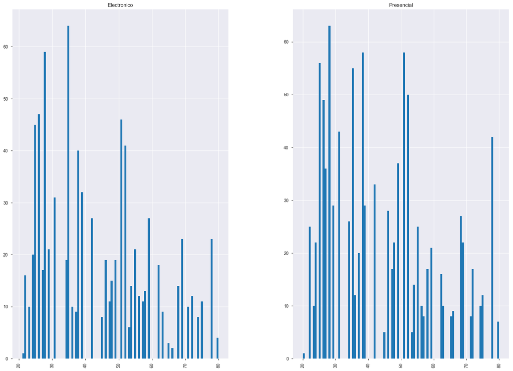

```python
# Estoy usando el dataframe que limpie rapidamente
dfPrinV2.hist('Edad',by='MedioPago',figsize=(20,15),bins=100)
```

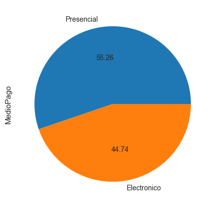

```python
# Haciendo pie chart dado MEDIO DE PAGO
dfPrinV2.MedioPago.value_counts().plot(kind='pie',figsize=(5, 5),autopct='%.2f')
```

```python
# Que tipo de variables son Medio de Pago y Rango de Edad ?
# Haciendo tabla de contingencia
TablaH1 = pd.crosstab(index=dfPrinV2.MedioPago,columns = dfPrinV2['Rango_Edad'],margins = True)
```

```python
TablaH1
```

| Rango_Edad MedioPago | a_Mayor_50 | b_Menor_50_mayor_30 | c_Menor_30 | All |
| --- | --- | --- | --- | --- |
| Electronico | 330 | 304 | 234 | 868 |
| Presencial | 398 | 385 | 289 | 1072 |
| All | 728 | 689 | 523 | 1940 |

```python
TablaH1.index = ["Electronico","Presencial","TOTAL_RANGO_EDAD"]
TablaH1.columns=["a_Mayor_50","b_Menor_50_mayor_30","c_Menor_30","TOTAL_MEDIO_DE_PAGO"]
```

## OJO: Piense cuando una tabla de contingencia no cumple los requisitos para hacer Chi-cuadrado ? . Esto lo vieron en clase :)

```python
TablaH1
```

|  | a_Mayor_50 | b_Menor_50_mayor_30 | c_Menor_30 | TOTAL_MEDIO_DE_PAGO |
| --- | --- | --- | --- | --- |
| Electronico | 330 | 304 | 234 | 868 |
| Presencial | 398 | 385 | 289 | 1072 |
| TOTAL_RANGO_EDAD | 728 | 689 | 523 | 1940 |

```python
# Total sobre filas y columnas
TablaH1/TablaH1.ix['TOTAL_RANGO_EDAD','TOTAL_MEDIO_DE_PAGO']
```

|  | a_Mayor_50 | b_Menor_50_mayor_30 | c_Menor_30 | TOTAL_MEDIO_DE_PAGO |
| --- | --- | --- | --- | --- |
| Electronico | 0.170103 | 0.156701 | 0.120619 | 0.447423 |
| Presencial | 0.205155 | 0.198454 | 0.148969 | 0.552577 |
| TOTAL_RANGO_EDAD | 0.375258 | 0.355155 | 0.269588 | 1.000000 |

```python
# Total sobre filas
TablaH1/TablaH1.ix["TOTAL_RANGO_EDAD"]
```

|  | a_Mayor_50 | b_Menor_50_mayor_30 | c_Menor_30 | TOTAL_MEDIO_DE_PAGO |
| --- | --- | --- | --- | --- |
| Electronico | 0.453297 | 0.441219 | 0.447419 | 0.447423 |
| Presencial | 0.546703 | 0.558781 | 0.552581 | 0.552577 |
| TOTAL_RANGO_EDAD | 1.000000 | 1.000000 | 1.000000 | 1.000000 |

```python
# Total sobre columnas
TablaH1.div(TablaH1.TOTAL_MEDIO_DE_PAGO, axis=0)
```

|  | a_Mayor_50 | b_Menor_50_mayor_30 | c_Menor_30 | TOTAL_MEDIO_DE_PAGO |
| --- | --- | --- | --- | --- |
| Electronico | 0.380184 | 0.350230 | 0.269585 | 1.0 |
| Presencial | 0.371269 | 0.359142 | 0.269590 | 1.0 |
| TOTAL_RANGO_EDAD | 0.375258 | 0.355155 | 0.269588 | 1.0 |

```python
# Generando TablaH1 para hacer chi-cuadrado
TablaH1=pd.crosstab(index=dfPrinV2.MedioPago,columns=dfPrinV2["Rango_Edad"])
```

```python
TablaH1.index= ["Electronico","Presencial"]
TablaH1
# Se genero la tabla de contingencia
```

| Rango_Edad | a_Mayor_50 | b_Menor_50_mayor_30 | c_Menor_30 |
| --- | --- | --- | --- |
| Electronico | 330 | 304 | 234 |
| Presencial | 398 | 385 | 289 |

```python
# Haciendo prueba de chi-cuadrado
chi2_contingency(TablaH1)
```

```
(0.2088464653828308,
 0.90084395011802076,
 2,
 array([[ 325.72371134,  308.2742268 ,  234.00206186],
        [ 402.27628866,  380.7257732 ,  288.99793814]]))
```

```python
# Guardo el p-value en una variable para luego evaluarla
# dado las condiciones de abajo
pvalue = chi2_contingency(TablaH1)[1]
```

```python
# Usando prints y if para saber si acepto o no la hipotesis nula y
# asi concentrarme en el analisis
print("Hipotesis NULA:", "Las variables son independendientes")
print("P-Value:", pvalue)

pval = pvalue

if pval > 0.05:
    print("Accept NULL hypothesis - Las variables  son independientes es decir no son dependientes")
if pval < 0.05:
    print("Reject NULL hypothesis - Las variables son dependientes.")
```

```
Hipotesis NULA: Las variables son independendientes
P-Value: 0.900843950118
Accept NULL hypothesis - Las variables  son independientes es decir no son dependientes
```

## Recomendacion 4: Siempre es recomendable hacer una grafica para soportar los resultados estadisticos y ver otras tendencias

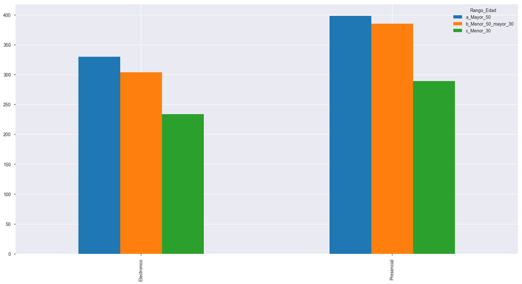

```python
TablaH1.plot(kind='bar',figsize=(20,10),legend=True)
```

## Respuesta

La edad no esta relacionada con el medio de pago en los datos, es decir no necesariamente los jovenes pagan con medio electronico.

El valor-p fue mayor a 0.05 por lo cual no se puede rechazar la hipotesis nula

## PRACTICA: En serio les recomiendo que repitan el ejercicio anterior y hagan los dos puntos de abajo

### 1. Hagan una hipotesis para que sea evaluada con pruebas de correlaciones y evaluan la hipotesis nula de la prueba

### 2. Hagan una hipotesis para que sea evaluada con pruebas de chi-cuadrado, cambiando una variable numerica a una categorica de acuerdo a las diapositivas de 6-11 de la Sesion 6. Estadistica Bivariada